# DisenhoFactorial2k-ejemplo-6.1

## Read dataset

```r
abono1<-read.table("abono1.txt",header=T)
str(abono1)
```

```
## 'data.frame':    24 obs. of  4 variables:
##  $ rend   : num  1.9 2.3 2 2.1 1.8 2.1 2.4 2.9 2.7 2.4 ...
##  $ abono  : Factor w/ 2 levels "a1","a2": 1 1 1 1 1 1 1 1 1 1 ...
##  $ dosis  : Factor w/ 3 levels "b1","b2","b3": 1 1 1 1 2 2 2 2 3 3 ...
##  $ bloques: int  1 2 3 4 1 2 3 4 1 2 ...
```

## Transformation Factor

```r
rend<-abono1$rend
bloques<-as.factor(abono1$bloques)
dosis<-as.factor(abono1$dosis)
tipo<-as.factor(abono1$abono)
```

## Define model

```r
mod<-lm(rend~bloques+tipo+dosis+tipo*dosis)
```

# Disenho Factorial 2k

Ejercicio: Considere una investigación llevada a cabo para estudiar el efecto que tienen la concentración de un reactivo y la presencia de un catalizador sobre el tiempo de reacción de un proceso químico. Sea la concentración del reactivo el factor A con dos niveles de interés, 15 y 25%. El catalizador constituye el factor B; el nivel alto (o superior) denota el uso de dos sacos de catalizador y el nivel bajo (o inferior) denota el uso de sólo un saco. El experimento se realiza (“réplica” o “repite”) tres veces, y los datos son como sigue:

```
## creating full factorial with 4 runs ...
```

```
##    run.no run.no.std.rp one two Blocks
## 1       1           4.1  25   2     .1
## 2       2           1.1  15   1     .1
## 3       3           2.1  25   1     .1
## 4       4           3.1  15   2     .1
## 5       5           3.2  15   2     .2
## 6       6           2.2  25   1     .2
## 7       7           4.2  25   2     .2
## 8       8           1.2  15   1     .2
## 9       9           1.3  15   1     .3
## 10     10           4.3  25   2     .3
## 11     11           2.3  25   1     .3
## 12     12           3.3  15   2     .3
## class=design, type= full factorial
## NOTE: columns run.no and run.no.std.rp  are annotation,
##  not part of the data frame
```

```r
y   <- c(28,25,27,36,32,32,18,19,23,31,30,29)
A   <- rep(c(rep(-1,3),rep(1,3)),2)
A
```

```
##  [1] -1 -1 -1  1  1  1 -1 -1 -1  1  1  1
```

```r
B   <- c(rep(-1,6),rep(1,6))
B
```

```
##  [1] -1 -1 -1 -1 -1 -1  1  1  1  1  1  1
```

```r
AB  <- A*B
AB
```

```
##  [1]  1  1  1 -1 -1 -1 -1 -1 -1  1  1  1
```

```r
XA  <- data.frame(y,A)
XA
```

```
##     y  A
## 1  28 -1
## 2  25 -1
## 3  27 -1
## 4  36  1
## 5  32  1
## 6  32  1
## 7  18 -1
## 8  19 -1
## 9  23 -1
## 10 31  1
## 11 30  1
## 12 29  1
```

```r
XAn <- XA[XA$A==-1,]
XAn
```

```
##    y  A
## 1 28 -1
## 2 25 -1
## 3 27 -1
## 7 18 -1
## 8 19 -1
## 9 23 -1
```

```r
XAp <- XA[XA$A==1,]
XAp
```

```
##     y A
## 4  36 1
## 5  32 1
## 6  32 1
## 10 31 1
## 11 30 1
## 12 29 1
```

```r
A <- mean(XAp$y)-mean(XAn$y)
A
```

```
## [1] 8.333333
```

```r
XB  <- data.frame(y,B)
XB
```

```
##     y  B
## 1  28 -1
## 2  25 -1
## 3  27 -1
## 4  36 -1
## 5  32 -1
## 6  32 -1
## 7  18  1
## 8  19  1
## 9  23  1
## 10 31  1
## 11 30  1
## 12 29  1
```

```r
XBp <- XB[XB$B==1,]
XBp
```

```
##     y B
## 7  18 1
## 8  19 1
## 9  23 1
## 10 31 1
## 11 30 1
## 12 29 1
```

```r
XBn <- XB[XB$B==-1,]
XBn
```

```
##    y  B
## 1 28 -1
## 2 25 -1
## 3 27 -1
## 4 36 -1
## 5 32 -1
## 6 32 -1
```

```r
B <- mean(XBp$y)-mean(XBn$y)
B
```

```
## [1] -5
```

Explicaci'on : Pasar del nivel bajo al nivel alto de B el promedio es negativo, Se interpreta que el rendimiento promedio obtenido con el nivel alto de B es inferior al rendimiento promedio obtenido con el nivel bajo de B es 5 unidades.

Si es positivo el rendimiento promedio del nivel alto de B es mayor al rendimiento promedio del nivel bajo de B.

```r
XAB <- data.frame(y,AB)
XABp <- XAB[XAB$AB == 1,]
XABn <- XAB[XAB$AB == -1,]

contrasteAB <- sum(XABp$y)-sum(XABn$y)
AB <- contrasteAB/(2*3)
AB
```

```
## [1] 1.666667
```

## Analisis de Varianza

Si p_value < 0.001, la prueba resulta muy altamente significativa, se rechaza $H_{0}$ y se denota con ***

$$y=\beta_{0} + \beta_{1}*x_{1} + \beta_{2}*x_{2} + \beta_{12}*x_{1}*x_{2} +\epsilon$$

$x_i$ = -1 si el factor de i se encuentra en el nivel bajo

$x_i$ = 1 si el factor de i se encuentra en el nivel alto

## Continuando con el ejemplo 6.1

```r
y <- c(28,25,27,36,32,32,18,19,23,31,30,29)
A <- rep(c(rep(-1,3),rep(1,3)),2)
B <- c(rep(-1,6),rep(1,6))
mod <- lm(y~A+B+A*B)
summary(mod)
```

```
##
## Call:
## lm.default(formula = y ~ A + B + A * B)
##
## Residuals:
##    Min     1Q Median     3Q    Max
## -2.000 -1.333 -0.500  1.083  3.000
##
## Coefficients:
##             Estimate Std. Error t value Pr(>|t|)
## (Intercept)  27.5000     0.5713  48.135 3.84e-11 ***
## A             4.1667     0.5713   7.293 8.44e-05 ***
## B            -2.5000     0.5713  -4.376  0.00236 **
## A:B           0.8333     0.5713   1.459  0.18278
## ---
## Signif. codes:  0 '***' 0.001 '**' 0.01 '*' 0.05 '.' 0.1 ' ' 1
##
## Residual standard error: 1.979 on 8 degrees of freedom
## Multiple R-squared:  0.903,  Adjusted R-squared:  0.8666
## F-statistic: 24.82 on 3 and 8 DF,  p-value: 0.0002093
```

Otra forma de encontrar los efectos estimados

```r
betaest <- coefficients(mod)
summary(betaest)
```

```
##    Min. 1st Qu.  Median    Mean 3rd Qu.    Max.
##    -2.5     0.0     2.5     7.5    10.0    27.5
```

Mostrar los coeficientes de regresi'on

```r
betaest
```

```
## (Intercept)           A           B         A:B
##  27.5000000   4.1666667  -2.5000000   0.8333333
```

```r
efectosest <- 2*betaest[2:4]
# efectosest
data.frame(efectosest)
```

```
##     efectosest
## A     8.333333
## B    -5.000000
## A:B   1.666667
```

Reemplazando en el modelo

```r
anva<-aov(mod)
summary(anva)
```

```
##             Df Sum Sq Mean Sq F value   Pr(>F)
## A            1 208.33  208.33  53.191 8.44e-05 ***
## B            1  75.00   75.00  19.149  0.00236 **
## A:B          1   8.33    8.33   2.128  0.18278
## Residuals    8  31.33    3.92
## ---
## Signif. codes:  0 '***' 0.001 '**' 0.01 '*' 0.05 '.' 0.1 ' ' 1
```

Se puede concluir que ambos efectos principales: concentración de reactivo y cantidad de catalizador influyen significativamente a un nivel del 1%. En cambio, La prueba de hipótesis sobre el efecto de la interacción (concentración de reactivo y cantidad de catalizador) resultó no significativa a un nivel del 10%.

## Analisis de los errores de los residuales :

Residuales

```r
mod1 <- lm(y~A+B)
CME <- deviance(mod1)/df.residual(mod1)

beta1 <- coefficients(mod1)
I <- rep(1,length(y))
X <- cbind(I,A,B)

yest <- X%*%beta1
e <- y-yest
e
```

```
##             [,1]
##  [1,]  2.1666667
##  [2,] -0.8333333
##  [3,]  1.1666667
##  [4,]  1.8333333
##  [5,] -2.1666667
##  [6,] -2.1666667
##  [7,] -2.8333333
##  [8,] -1.8333333
##  [9,]  2.1666667
## [10,]  1.8333333
## [11,]  0.8333333
## [12,] -0.1666667
```

Otra manera de ver los residuales

```r
e1 <- residuals(mod1)
data.frame(e1)
```

```
##            e1
## 1   2.1666667
## 2  -0.8333333
## 3   1.1666667
## 4   1.8333333
## 5  -2.1666667
## 6  -2.1666667
## 7  -2.8333333
## 8  -1.8333333
## 9   2.1666667
## 10  1.8333333
## 11  0.8333333
## 12 -0.1666667
```

## Se obtiene los residuales estudentizados

```r
H  <- X%*%solve(t(X)%*%X)%*%t(X)
ri <- e/sqrt(CME*(1-diag(H)))
ri
```

```
##              [,1]
##  [1,]  1.19170805
##  [2,] -0.45834925
##  [3,]  0.64168895
##  [4,]  1.00836835
##  [5,] -1.19170805
##  [6,] -1.19170805
##  [7,] -1.55838744
##  [8,] -1.00836835
##  [9,]  1.19170805
## [10,]  1.00836835
## [11,]  0.45834925
## [12,] -0.09166985
```

Otra forma de encontrar los residuales estudentizados

```r
ri <- rstandard(mod1)
data.frame(ri)
```

```
##             ri
## 1   1.19170805
## 2  -0.45834925
## 3   0.64168895
## 4   1.00836835
## 5  -1.19170805
## 6  -1.19170805
## 7  -1.55838744
## 8  -1.00836835
## 9   1.19170805
## 10  1.00836835
## 11  0.45834925
## 12 -0.09166985
```

Grafico de los residuos y residuos estudentizdos

```
## hat values (leverages) are all = 0.25
##  and there are no factor predictors; no plot no. 5
```

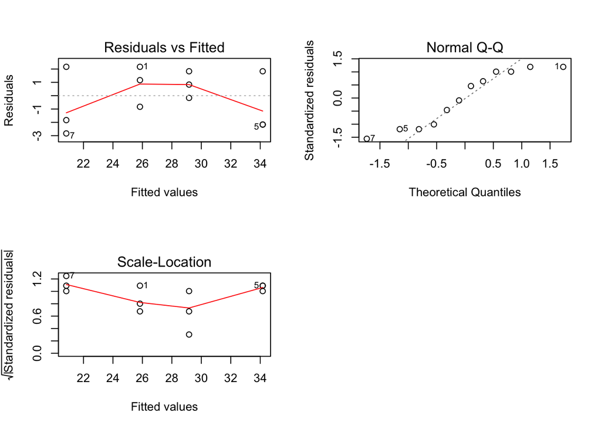

```r
par(mfrow=c(2,2))
plot(mod1)
```

$H_0$ : la muestra x1, …, xn proviene de una población normalmente distribuida. $H_1$ : la muestra x1, …, xn no proviene de una población normalmente distribuida.

```r
shapiro.test(ri)
```

```
##
##  Shapiro-Wilk normality test
##
## data:  ri
## W = 0.88179, p-value = 0.09239
```

A un nivel de significación del 10% se ha encontrado suficiente evidencia para afirmar que los errores no se distribuyen normalmente

```r
library(car)
ncvTest(mod1)
```

```
## Non-constant Variance Score Test
## Variance formula: ~ fitted.values
## Chisquare = 0.1148473, Df = 1, p = 0.73469
```

## Prueba de variancia constante de errores Breusch-Pagan.

Test de Breusch-Pagan:

$H_0$ : Existe homogeneidad de variancia de los errores $H_1$ : No existe homogeneidad de variancia de los errores

Gráfico de variabilidad de los residuales a nivel alto del factor versus la variabilidad de los residuos a nivel bajo, para el ejemplo 6.1

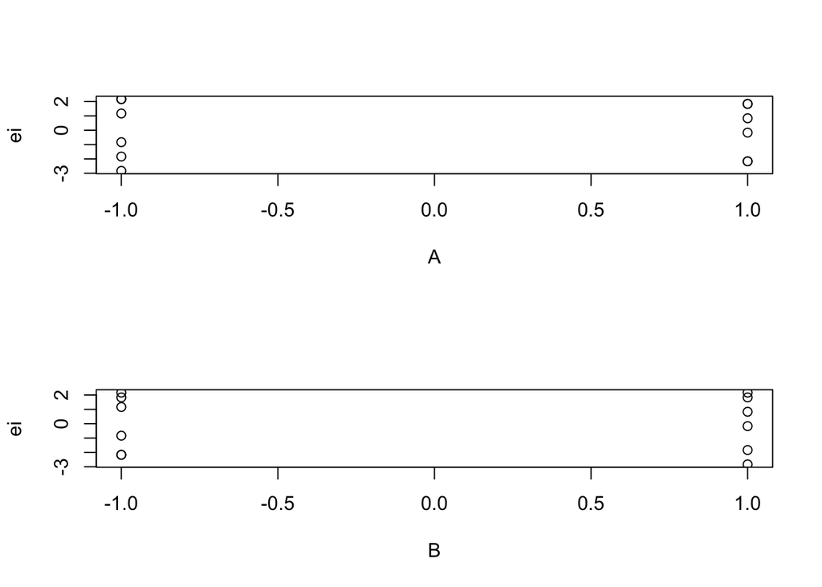

```r
ei <- residuals(mod1)
par(mfrow=c(2,1))
plot(A,ei)
plot(B,ei)
```

Grap 2 : La variabilidad para B- -1.0 es poco variable en la parte superior y mas variable en la parte de abajo

## Prueba de variabilidad

Prueba de variabilidad de los residuales a nivel alto del factor versus la variabilidad de los residuos a nivel bajo:

```r
dataA <- data.frame(ei,A)
dataAn <- dataA[dataA$A == -1,]
dataAn
```

```
##           ei  A
## 1  2.1666667 -1
## 2 -0.8333333 -1
## 3  1.1666667 -1
## 7 -2.8333333 -1
## 8 -1.8333333 -1
## 9  2.1666667 -1
```

```r
dataAp <- dataA[dataA$A == 1,]
dataAp
```

```
##            ei A
## 4   1.8333333 1
## 5  -2.1666667 1
## 6  -2.1666667 1
## 10  1.8333333 1
## 11  0.8333333 1
## 12 -0.1666667 1
```

Construyo la estadistica de prueba

```r
F <- log(var(dataAp$ei)/var(dataAn$ei))
F
```

```
## [1] -0.3048604
```

```r
pvalue <- 2*pnorm(F)
pvalue
```

```
## [1] 0.7604725
```

No hay diferencia significativas entre la variabilidad del nivel alto y bajo de A

## Para B

```r
dataB <- data.frame(ei,B)
dataBn <- dataB[dataB$B == -1,]
dataBn
```

```
##           ei  B
## 1  2.1666667 -1
## 2 -0.8333333 -1
## 3  1.1666667 -1
## 4  1.8333333 -1
## 5 -2.1666667 -1
## 6 -2.1666667 -1
```

```r
dataBp <- dataB[dataB$B == 1,]
dataBp
```

```
##            ei B
## 7  -2.8333333 1
## 8  -1.8333333 1
## 9   2.1666667 1
## 10  1.8333333 1
## 11  0.8333333 1
## 12 -0.1666667 1
```

```r
F <- log(var(dataBp$ei)/var(dataBn$ei))
F
```

```
## [1] 0.03361661
```

```r
pvalue<-2*(1-pnorm(F))
pvalue
```

```
## [1] 0.9731829
```

No hay diferencia significativas entre la variabilidad del nivel alto y bajo de B

## Gráfica de la superficie

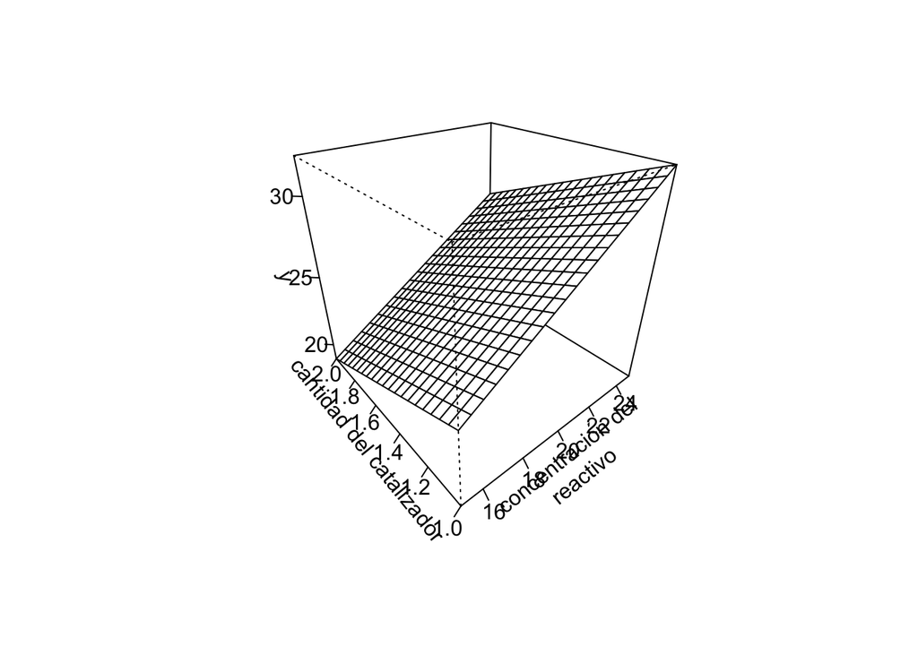

```r
mod <- function(x1,x2){
  16.3333 + 0.83333*x1 - 5*x2
}

x1 <- seq(15,25,0.5)
x2 <- seq(1,2,0.05)

z <- outer(x1,x2,mod)

persp(x1,x2,z,theta=-40,phi=30,ticktype="detailed",xlab="concentración del
reactivo",ylab="cantidad del catalizador", zlab="y")
```

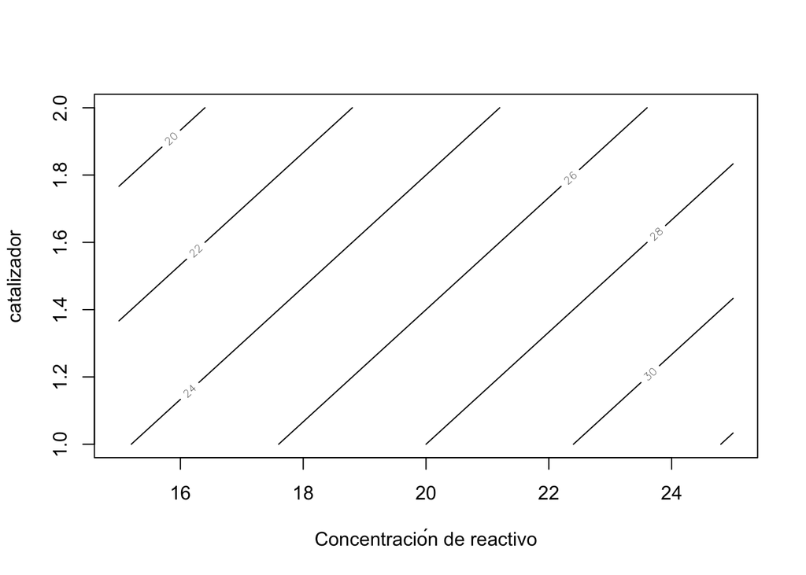

```r
contour(x1,x2,z,nlevels=6,xlab="Concentración de reactivo", ylab="cantidad de
catalizador")
```

```r
printmat <- function(msg, mat) {
  out <- capture.output(mat)
  sprintf("%s: %s", msg, out)
}


A <- rep(c(-1,1),4)
printmat("A ",A)
```

```
## [1] "A : [1] -1  1 -1  1 -1  1 -1  1"
```

```r
B <- rep(c(rep(-1,2),rep(1,2)),2)
printmat("B ",B)
```

```
## [1] "B : [1] -1 -1  1  1 -1 -1  1  1"
```

```r
C <- c(rep(-1,4),rep(1,4))
printmat("C ",C)
```

```
## [1] "C : [1] -1 -1 -1 -1  1  1  1  1"
```

```r
#
y1 <- c(-3,0,-1,2,-1,2,1,6)
y2 <- c(-1,1,0,3,0,1,1,5)
y <- y1 + y2
printmat("y ",y)
```

```
## [1] "y : [1] -4  1 -1  5 -1  3  2 11"
```

```r
ym <- c(y1,y2)
printmat("ym",ym)
```

```
## [1] "ym:  [1] -3  0 -1  2 -1  2  1  6 -1  1  0  3  0  1  1  5"
```

```r
# Defino repiticiones
A1 <- rep(A,2)
printmat("A1",A1)
```

```
## [1] "A1:  [1] -1  1 -1  1 -1  1 -1  1 -1  1 -1  1 -1  1 -1  1"
```

```r
B1 <- rep(B,2)
printmat("B1",B1)
```

```
## [1] "B1:  [1] -1 -1  1  1 -1 -1  1  1 -1 -1  1  1 -1 -1  1  1"
```

```r
C1 <- rep(C,2)
printmat("C1",C1)
```

```
## [1] "C1:  [1] -1 -1 -1 -1  1  1  1  1 -1 -1 -1 -1  1  1  1  1"
```

Todo el modelo

```r
mod <- lm( y ~ A*B*C)
summary(mod)
```

```
##
## Call:
## lm.default(formula = y ~ A * B * C)
##
## Residuals:
## ALL 8 residuals are 0: no residual degrees of freedom!
##
## Coefficients:
##             Estimate Std. Error t value Pr(>|t|)
## (Intercept)     2.00         NA      NA       NA
## A               3.00         NA      NA       NA
## B               2.25         NA      NA       NA
## C               1.75         NA      NA       NA
## A:B             0.75         NA      NA       NA
## A:C             0.25         NA      NA       NA
## B:C             0.50         NA      NA       NA
## A:B:C           0.50         NA      NA       NA
##
## Residual standard error: NaN on 0 degrees of freedom
## Multiple R-squared:      1,  Adjusted R-squared:    NaN
## F-statistic:   NaN on 7 and 0 DF,  p-value: NA
```

Todo el modelo

```r
mod <- lm( ym ~ A1*B1*C1)
summary(mod)
```

```
##
## Call:
## lm.default(formula = ym ~ A1 * B1 * C1)
##
## Residuals:
##    Min     1Q Median     3Q    Max
##   -1.0   -0.5    0.0    0.5    1.0
##
## Coefficients:
##             Estimate Std. Error t value Pr(>|t|)
## (Intercept)   1.0000     0.1976   5.060 0.000977 ***
## A1            1.5000     0.1976   7.589 6.37e-05 ***
## B1            1.1250     0.1976   5.692 0.000459 ***
## C1            0.8750     0.1976   4.427 0.002205 **
## A1:B1         0.3750     0.1976   1.897 0.094350 .
## A1:C1         0.1250     0.1976   0.632 0.544737
## B1:C1         0.2500     0.1976   1.265 0.241504
## A1:B1:C1      0.2500     0.1976   1.265 0.241504
## ---
## Signif. codes:  0 '***' 0.001 '**' 0.01 '*' 0.05 '.' 0.1 ' ' 1
##
## Residual standard error: 0.7906 on 8 degrees of freedom
## Multiple R-squared:  0.9359, Adjusted R-squared:  0.8798
## F-statistic: 16.69 on 7 and 8 DF,  p-value: 0.0003474
```

Se muestran los efectos estimados

```r
betaest <- coefficients(mod)
efectoest <- 2*betaest[-1]
data.frame(efectoest)
```

```
##          efectoest
## A1            3.00
## B1            2.25
## C1            1.75
## A1:B1         0.75
## A1:C1         0.25
## B1:C1         0.50
## A1:B1:C1      0.50
```

```r
anva <- aov(mod)
summary(anva)
```

```
##             Df Sum Sq Mean Sq F value   Pr(>F)
## A1           1  36.00   36.00    57.6 6.37e-05 ***
## B1           1  20.25   20.25    32.4 0.000459 ***
## C1           1  12.25   12.25    19.6 0.002205 **
## A1:B1        1   2.25    2.25     3.6 0.094350 .
## A1:C1        1   0.25    0.25     0.4 0.544737
## B1:C1        1   1.00    1.00     1.6 0.241504
## A1:B1:C1     1   1.00    1.00     1.6 0.241504
## Residuals    8   5.00    0.63
## ---
## Signif. codes:  0 '***' 0.001 '**' 0.01 '*' 0.05 '.' 0.1 ' ' 1
```

```r
y <- c(-3,0,-1,2,-1,2,1,6,-1,1,0,3,0,1,1,5)
printmat("y ",y)
```

```
## [1] "y :  [1] -3  0 -1  2 -1  2  1  6 -1  1  0  3  0  1  1  5"
```

```r
A <- rep(c(-1,1),8)
printmat("A ",A)
```

```
## [1] "A :  [1] -1  1 -1  1 -1  1 -1  1 -1  1 -1  1 -1  1 -1  1"
```

```r
B <- rep(c(-1,-1,1,1),4)
printmat("B ",B)
```

```
## [1] "B :  [1] -1 -1  1  1 -1 -1  1  1 -1 -1  1  1 -1 -1  1  1"
```

```r
C <- rep(c(rep(-1,4),rep(1,4)),2)
printmat("C ",C)
```

```
## [1] "C :  [1] -1 -1 -1 -1  1  1  1  1 -1 -1 -1 -1  1  1  1  1"
```

```r
datac  <- data.frame(y,C)
datacp <- datac[datac$C == 1,]
printmat("datacp ",datacp)
```

```
## [1] "datacp :     y C" "datacp : 5  -1 1" "datacp : 6   2 1"
## [4] "datacp : 7   1 1" "datacp : 8   6 1" "datacp : 13  0 1"
## [7] "datacp : 14  1 1" "datacp : 15  1 1" "datacp : 16  5 1"
```

```r
datacn <- datac[datac$C == -1,]
printmat("datacn ",datacn)
```

```
## [1] "datacn :     y  C" "datacn : 1  -3 -1" "datacn : 2   0 -1"
## [4] "datacn : 3  -1 -1" "datacn : 4   2 -1" "datacn : 9  -1 -1"
## [7] "datacn : 10  1 -1" "datacn : 11  0 -1" "datacn : 12  3 -1"
```

```r
ycn <- mean(datacn$y)
ypp <- mean(datacp$y)
nC  <- c(-1,1)
ypC <-c(ycn,ypp)
ypC
```

```
## [1] 0.125 1.875
```

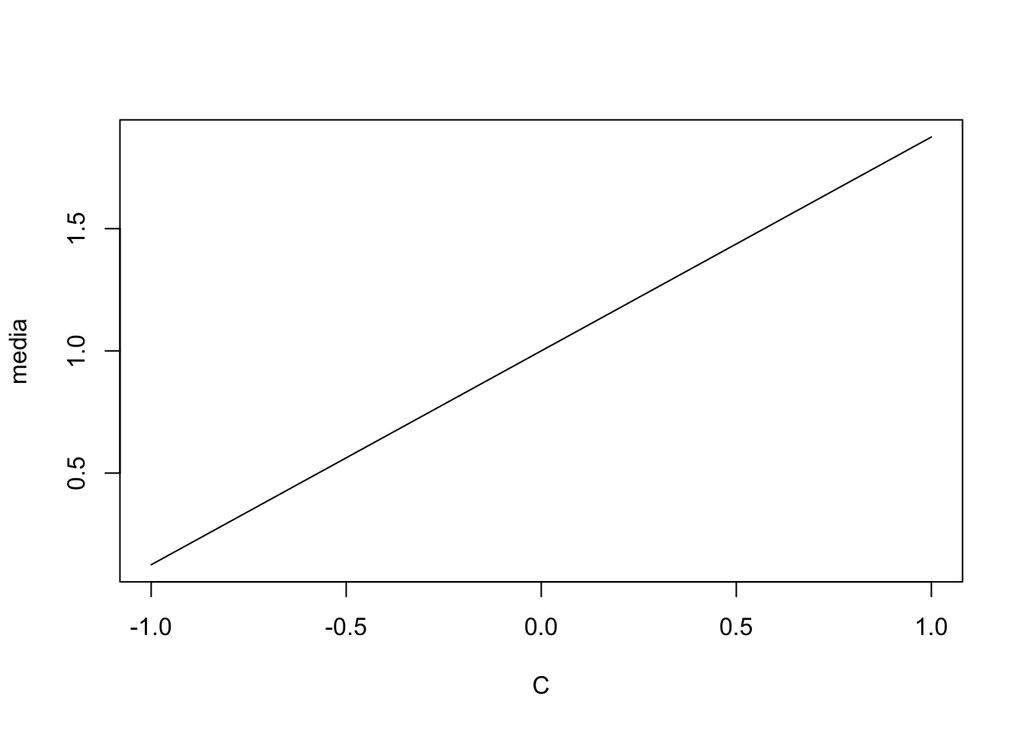

```r
plot(nC,ypC,type="l",xlab="C",ylab="media")
```

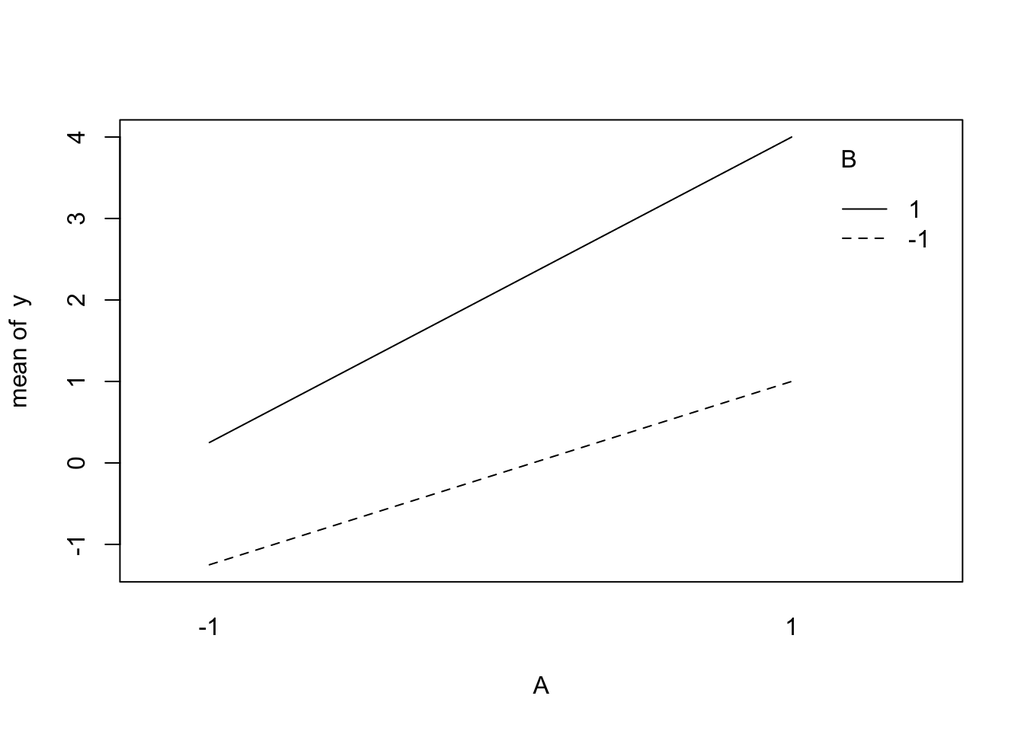

```r
interaction.plot(A,B,y)
```

Analisis de residuos

```r
y <- c(-3,0,-1,2,-1,2,1,6,-1,1,0,3,0,1,1,5)
printmat("y ",y)
```

```
## [1] "y :  [1] -3  0 -1  2 -1  2  1  6 -1  1  0  3  0  1  1  5"
```

```r
A <- rep(c(-1,1),8)
printmat("A ",A)
```

```
## [1] "A :  [1] -1  1 -1  1 -1  1 -1  1 -1  1 -1  1 -1  1 -1  1"
```

```r
B <- rep(c(-1,-1,1,1),4)
printmat("B ",B)
```

```
## [1] "B :  [1] -1 -1  1  1 -1 -1  1  1 -1 -1  1  1 -1 -1  1  1"
```

```r
C <- rep(c(rep(-1,4),rep(1,4)),2)
printmat("C ",C)
```

```
## [1] "C :  [1] -1 -1 -1 -1  1  1  1  1 -1 -1 -1 -1  1  1  1  1"
```

```r
mod1 <- lm(y ~ A*B*C)
betaest <- coefficients(mod1)
betaest
```

```
## (Intercept)           A           B           C         A:B         A:C
##       1.000       1.500       1.125       0.875       0.375       0.125
##         B:C       A:B:C
##       0.250       0.250
```

```r
efectos <- 2*betaest[2:8]
efectos
```

```
##     A     B     C   A:B   A:C   B:C A:B:C
##  3.00  2.25  1.75  0.75  0.25  0.50  0.50
```

```
## hat values (leverages) are all = 0.5
##  and there are no factor predictors; no plot no. 5
```

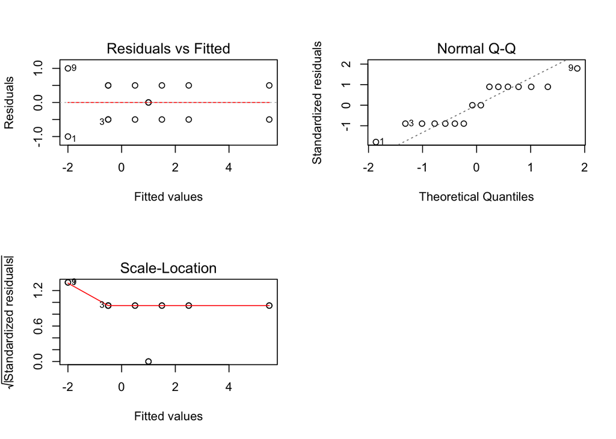

```r
par(mfrow=c(2,2))
plot(mod1)
```

```r
ri<-rstandard(mod1)
shapiro.test(ri)
```

```
##
##  Shapiro-Wilk normality test
##
## data:  ri
## W = 0.87436, p-value = 0.03173
```

```r
library(car)
ncvTest(mod1)
```

```
## Non-constant Variance Score Test
## Variance formula: ~ fitted.values
## Chisquare = 1.420274, Df = 1, p = 0.23336
```

```r
A
```

```
##  [1] -1  1 -1  1 -1  1 -1  1 -1  1 -1  1 -1  1 -1  1
```

```r
B
```

```
##  [1] -1 -1  1  1 -1 -1  1  1 -1 -1  1  1 -1 -1  1  1
```

```r
C
```

```
##  [1] -1 -1 -1 -1  1  1  1  1 -1 -1 -1 -1  1  1  1  1
```

```r
ei<-residuals(mod1)
ei
```

```
##             1             2             3             4             5
## -1.000000e+00 -5.000000e-01 -5.000000e-01 -5.000000e-01 -5.000000e-01
##             6             7             8             9            10
##  5.000000e-01  1.665335e-16  5.000000e-01  1.000000e+00  5.000000e-01
##            11            12            13            14            15
##  5.000000e-01  5.000000e-01  5.000000e-01 -5.000000e-01 -1.110223e-16
##            16
## -5.000000e-01
```

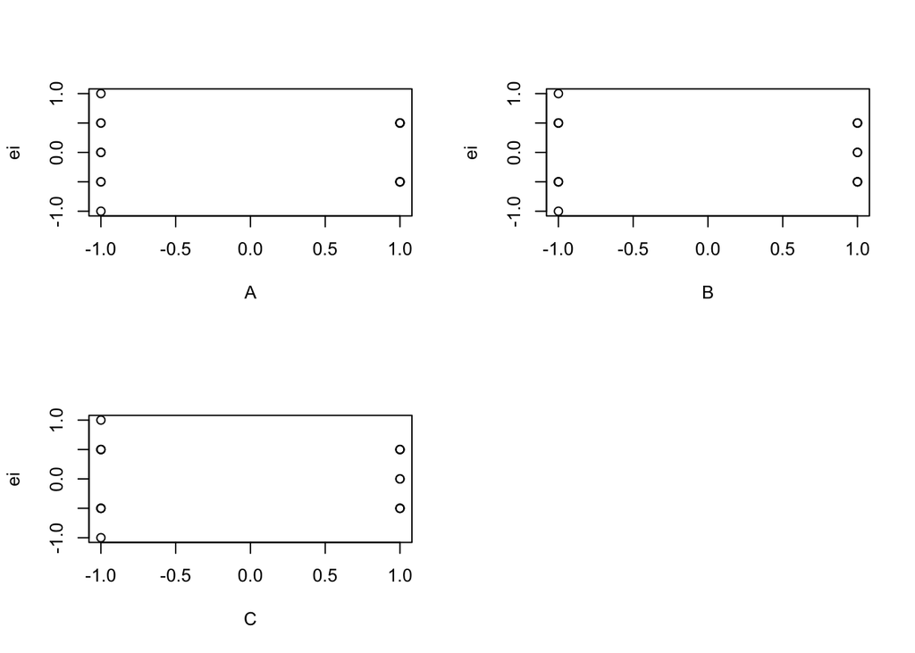

```r
par(mfrow=c(2,2))
plot(A,ei)
plot(B,ei)
plot(C,ei)
```

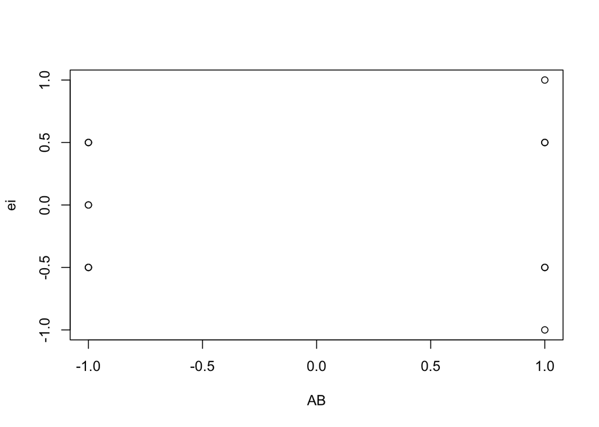

```r
AB <- A*B
plot(AB,ei)
```